# Introduction to Shiny

Session 1: *Introduction to Shiny*

Danny Smith

# Housekeeping

## Course outline

1. *Introduction to Shiny*
2. Shiny UI - layout, styling and theming
3. Shiny UI - dynamic UI and extensions
4. Reactivity and the user session
5. Shiny modules, working with data
6. Application structure and workflow

## What will we learn?

A high level overview of Shiny, dipping into detail for key topics

**Concepts**

What is Shiny and how do the key components work?

**Extending**

How do you customise and extend Shiny?

**Resources**

How do you learn more as your needs change?

**In practice**

Workflow, best practices and some non-Shiny bits

## Requirements

#### Knowledge

- Comfortable working knowledge of R
- Familiarity with RStudio

#### Tools

- R
- RStudio
- Shiny!

  ```r
  install.packages("shiny")
  ```

## Resources

#### Session materials

[GitHub repo](https://github.com/gorcha/r_shiny_intro_data)

```bash
git clone https://github.com/gorcha/r_shiny_intro_data.git
```

#### Online resources

[Mastering Shiny](https://mastering-shiny.org)

[Shiny Learning Resources](https://shiny.rstudio.com/tutorial/)

[RStudio Shiny documentation](https://shiny.rstudio.com/articles)

## This session

- Introduction to Shiny
- Creating an application
- Basic application structure
- Intro to UI code
- Intro to Server code
- Reactivity

# Introduction to Shiny

## What is Shiny?

[Shiny](https://shiny.rstudio.com) is an R package allowing users to easily create interactive data driven web applications using only R code.

- Incredibly fast to develop simple apps
- Only R knowledge required, but a bit of web programming helps
- Initial release in 2012

[Shiny Gallery](https://shiny.rstudio.com/gallery/)

## What is a Shiny application?

A web application defined in R code, accessible in the browser.

**UI - the frontend interface**

How the app *looks*. This defines what the user will see in their browser.

**Server - backend application logic**

How the app *behaves*. This defines the interaction of UI elements (how user inputs are used, how output data is produced) and other application behaviour.

## How does an application run?

The `shiny::runApp()` function

- Runs a web server
- Waits for user connections/requests

  ```
  Listening on http://127.0.0.1:3771
  ```

- Communicates with user sessions to allow user interaction

```r
runApp(
  appDir = getwd(),
  port = getOption("shiny.port"),
  launch.browser = getOption("shiny.launch.browser", interactive()),
  host = getOption("shiny.host", "127.0.0.1"),
  workerId = "",
  quiet = FALSE,
  display.mode = c("auto", "normal", "showcase"),
  test.mode = getOption("shiny.testmode", FALSE)
)
```

# Creating an application

## Creating an application: Shiny

```r
library(shiny)
```

## Creating an application: UI

**UI**: how the app *looks*

- Layout and components
- Functions output HTML to be rendered in the browser

```r
library(shiny)

ui <- fluidPage(
  selectInput("dataset", label = "Dataset", choices = ls("package:datasets")),
  tableOutput("table")
)
```

```r
print(tableOutput("table"))
```

```
<div id="table" class="shiny-html-output"></div>
```

## Creating an application: Server

**UI**: how the app *looks*

**Server**: how the app *behaves*

- Process `input`s
- Update `output`s
- Manipulate the user `session`

```r
library(shiny)

ui <- fluidPage(
  selectInput("dataset", label = "Dataset", choices = ls("package:datasets")),
  tableOutput("table")
)

server <- function(input, output, session) {
  output$table <- renderTable({
    dataset <- get(input$dataset, "package:datasets")
    dataset
  })
}
```

## Creating an application: App object

**UI**: how the app *looks*

**Server**: how the app *behaves*

**App object**: how to *run* the app

- Combine the server and UI into a `shinyApp()` object
- Run this application with `runApp()`

```r
library(shiny)

ui <- fluidPage(
  selectInput("dataset", label = "Dataset", choices = ls("package:datasets")),
  tableOutput("table")
)

server <- function(input, output, session) {
  output$table <- renderTable({
    dataset <- get(input$dataset, "package:datasets")
    dataset
  })
}

app <- shinyApp(ui, server)
runApp(app)
```

📝 session_01/create_an_app.R

# Basic application structure

## app.R

- UI and server code in a single file
- Last expression in the file must return a `shinyApp()` object
- Good for small applications

```
shinyapp
└── app.R
```

```r
shiny::runApp("shinyapp/app.R")
shiny::runApp("shinyapp")
```

```
app.R
```

```r
library(shiny)

ui <- fluidPage(
  textOutput("hello")
)

server <- function(input, output, session) {
  output$hello <- renderText("Hello, world!")
}

shinyApp(ui, server)
```

📁 session_01/structure_single_file

## ui.R & server.R

- Separate UI and server
- Last expression in each file must be a ui object/server function
- Good for code management in larger applications

```
shinyapp
├── server.R
└── ui.R
```

```r
shiny::runApp("shinyapp")
```

```
ui.R
```

```r
ui <- fluidPage(
  textOutput("hello")
)
```

```
server.R
```

```r
library(shiny)

server <- function(input, output, session) {
  output$hello <- renderText("Hello, world!")
}
```

📁 session_01/structure_multi_file

## Additional files

#### global.R

- Run before server.R and ui.R
- Loaded into the global environment

```
shinyapp
├── global.R
├── server.R
└── ui.R
```

```r
shiny::runApp("shinyapp")
```

#### R sub-directory

- Files in the R directory are `source()`d in alphabetical order

```
shinyapp
├── R
│   ├── data_load.R
│   └── utils.R
├── global.R
├── server.R
└── ui.R
```

```r
shiny::runApp("shinyapp")
```

Discussed in more detail in session 6!

# Intro to UI code

📁 session_01/intro_app

## Layout

- Functions defining placement and styling of elements in the UI
- Containers that apply styling and positioning

```r
ui <- fluidPage(
  titlePanel("Miles Per Gallon"),

  sidebarLayout(
    sidebarPanel(
      selectInput(
        "variable",
        "Variable:",
        c("Cylinders" = "cyl", "Transmission" = "am", "Gears" = "gear")
      ),
      p("Simple text with a ", a("hyperlink", href = "#")),
      checkboxInput("outliers", "Show outliers", TRUE)
    ),

    mainPanel(
      h3(textOutput("caption")),
      plotOutput("mpg_plot")
    )
  )
)
```

- Interactive elements accepting user input
- Value accessible in server function

```r
ui <- fluidPage(
  titlePanel("Miles Per Gallon"),

  sidebarLayout(
    sidebarPanel(
      selectInput(
        "variable",
        "Variable:",
        c("Cylinders" = "cyl", "Transmission" = "am", "Gears" = "gear")
      ),
      p("Simple text with a ", a("hyperlink", href = "#")),
      checkboxInput("outliers", "Show outliers", TRUE)
    ),

    mainPanel(
      h3(textOutput("caption")),
      plotOutput("mpg_plot")
    )
  )
)
```

## Input functions

Most input functions share a common structure:

- `inputId` - the unique ID used to refer to this element
- `label` - a human readable label
- `value` - the default value
- Unique parameters for the control

```r
checkboxInput(
  inputId,
  label,
  value = FALSE,
  width = NULL
)
```

```r
selectInput(
  inputId,
  label,
  choices,
  selected = NULL,
  multiple = FALSE,
  selectize = TRUE,
  width = NULL,
  size = NULL
)
```

## Outputs

- Elements with dynamic content
- Content assigned in server function

```r
ui <- fluidPage(
  titlePanel("Miles Per Gallon"),

  sidebarLayout(
    sidebarPanel(
      selectInput(
        "variable",
        "Variable:",
        c("Cylinders" = "cyl", "Transmission" = "am", "Gears" = "gear")
      ),
      p("Simple text with a ", a("hyperlink", href = "#")),
      checkboxInput("outliers", "Show outliers", TRUE)
    ),

    mainPanel(
      h3(textOutput("caption")),
      plotOutput("mpg_plot")
    )
  )
)
```

## Output functions

Like inputs, most output functions take the unique ID in the first argument:

- `outputId` - the unique ID used to refer to this element
- Unique parameters for the control

```r
textOutput(
  outputId,
  container = if (inline) span else div,
  inline = FALSE
)
```

```r
plotOutput(
  outputId,
  width = "100%",
  height = "400px",
  click = NULL,
  dblclick = NULL,
  hover = NULL,
  brush = NULL,
  inline = FALSE
)
```

## Interface builders

- Static content
- HTML content tags
  - link `a()`
  - image `img()`
- HTML semantic tags
  - heading `h3()`
  - paragraph `p()`
  - styling `strong()`

```r
ui <- fluidPage(
  titlePanel("Miles Per Gallon"),

  sidebarLayout(
    sidebarPanel(
      selectInput(
        "variable",
        "Variable:",
        c("Cylinders" = "cyl", "Transmission" = "am", "Gears" = "gear")
      ),
      p("Simple text with a ", a("hyperlink", href = "#")),
      checkboxInput("outliers", "Show outliers", TRUE)
    ),

    mainPanel(
      h3(textOutput("caption")),
      plotOutput("mpg_plot")
    )
  )
)
```

## In practice

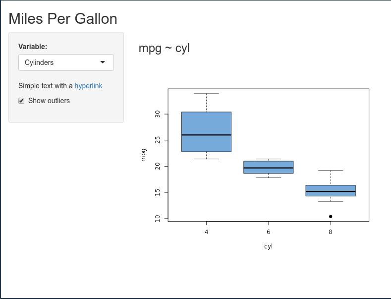

```r
ui <- fluidPage(
  titlePanel("Miles Per Gallon"),

  sidebarLayout(
    sidebarPanel(
      selectInput(
        "variable",
        "Variable:",
        c("Cylinders" = "cyl", "Transmission" = "am", "Gears" = "gear")
      ),
      p("Simple text with a ", a("hyperlink", href = "#")),
      checkboxInput("outliers", "Show outliers", TRUE)
    ),

    mainPanel(
      h3(textOutput("caption")),
      plotOutput("mpg_plot")
    )
  )
)
```

## Addendum: Metadata

- Most shiny UI functions are visible elements included in HTML `<body>`
- Metadata tags should be included in HTML `<head>`
  - Add with `tags$head()`
- Not included in this example, covered in later sessions

```html
<!DOCTYPE html>
<html lang="en-US">
  <head>
    <meta charset="utf-8" />
    <title>My test page</title>
  </head>
  <body>
    <p>This is my page</p>
  </body>
</html>
```

# Intro to Server code

📁 session_01/intro_app

## Server function

- The engine of your application, controlling the behaviour of UI elements
- A function taking three arguments: `input`, `output` and `session`
- Run once for each user session

```r
mpg_data <- mtcars
mpg_data$am <- factor(mpg_data$am, labels = c("Automatic", "Manual"))

server <- function(input, output, session) {
  formula_text <- reactive({
    paste("mpg ~", input$variable)
  })

  output$caption <- renderText({
    formula_text()
  })

  output$mpg_plot <- renderPlot({
    boxplot(
      as.formula(formula_text()),
      data = mpg_data,
      outline = input$outliers,
      col = "#75AADB",
      pch = 19
    )
  })
}
```

## `input`

Access values from UI input elements

- Environment containing references to inputs
- Use the input ID from the UI definition

  ```r
  selectInput("variable", ...)
  checkboxInput("outliers", ...)
  ```

- Values are *reactive*
- Read-only

```r
mpg_data <- mtcars
mpg_data$am <- factor(mpg_data$am, labels = c("Automatic", "Manual"))

server <- function(input, output, session) {
  formula_text <- reactive({
    paste("mpg ~", input$variable)
  })

  output$caption <- renderText({
    formula_text()
  })

  output$mpg_plot <- renderPlot({
    boxplot(
      as.formula(formula_text()),
      data = mpg_data,
      outline = input$outliers,
      col = "#75AADB",
      pch = 19
    )
  })
}
```

## `input` return values

Input elements return different data structures depending on the control

- Check out the help page!
- Most input functions have a “Server value” section

```r
?checkboxInput
```

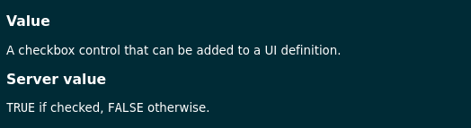

```r
?selectInput
```

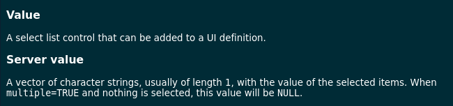

## `output`

Assign content to UI output elements

- Environment containing references to outputs
- Use the output ID from the UI definition

  ```r
  textOutput("caption")
  plotOutput("mpg_plot")
  ```

- Use a `render*()` function - a *reactive wrapper*

```r
mpg_data <- mtcars
mpg_data$am <- factor(mpg_data$am, labels = c("Automatic", "Manual"))

server <- function(input, output, session) {
  formula_text <- reactive({
    paste("mpg ~", input$variable)
  })

  output$caption <- renderText({
    formula_text()
  })

  output$mpg_plot <- renderPlot({
    boxplot(
      as.formula(formula_text()),
      data = mpg_data,
      outline = input$outliers,
      col = "#75AADB",
      pch = 19
    )
  })
}
```

## `render*()` functions

Output UI elements have a corresponding `render*()` function.

- Takes an expression that returns data for the output
- This expression becomes *reactive*
- Output element help page has the `render*()` function to use

```r
?textOutput
```

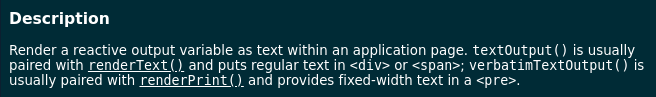

[figure not shown]

```r
?plotOutput
```

## Other reactives

`reactive()` creates a *reactive expression*

- An “expression whose result will change over time”
- Reduce duplication
- Compartmentalise code
- Call like a function

```r
mpg_data <- mtcars
mpg_data$am <- factor(mpg_data$am, labels = c("Automatic", "Manual"))

server <- function(input, output, session) {
  formula_text <- reactive({
    paste("mpg ~", input$variable)
  })

  output$caption <- renderText({
    formula_text()
  })

  output$mpg_plot <- renderPlot({
    boxplot(
      as.formula(formula_text()),
      data = mpg_data,
      outline = input$outliers,
      col = "#75AADB",
      pch = 19
    )
  })
}
```

## Shared objects

Additional arbitrary R code in server file

- Load libraries
- Load and preprocess data
- Declare helper functions
- Run once, results visible across all sessions

```r
mpg_data <- mtcars
mpg_data$am <- factor(mpg_data$am, labels = c("Automatic", "Manual"))

server <- function(input, output, session) {
  formula_text <- reactive({
    paste("mpg ~", input$variable)
  })

  output$caption <- renderText({
    formula_text()
  })

  output$mpg_plot <- renderPlot({
    boxplot(
      as.formula(formula_text()),
      data = mpg_data,
      outline = input$outliers,
      col = "#75AADB",
      pch = 19
    )
  })
}
```

## `session`

The `session` object is used to interact with the user session

- Client information
- Access control
- Complex applications

Discussed in more detail in session 4!

```r
mpg_data <- mtcars
mpg_data$am <- factor(mpg_data$am, labels = c("Automatic", "Manual"))

server <- function(input, output, session) {
  formula_text <- reactive({
    paste("mpg ~", input$variable)
  })

  output$caption <- renderText({
    formula_text()
  })

  output$mpg_plot <- renderPlot({
    boxplot(
      as.formula(formula_text()),
      data = mpg_data,
      outline = input$outliers,
      col = "#75AADB",
      pch = 19
    )
  })
}
```

# Reactivity

## What is reactivity?

- Shiny server logic is expressed using *reactivity*
- Updates user UI automatically, but only when necessary
  - “React” to changes
- Graph of *reactive dependencies*
  - What outputs depend on what inputs?
  - Other reactive components (e.g. reactive expressions)
  - Determines when code is executed and in what order

## Reactive graph

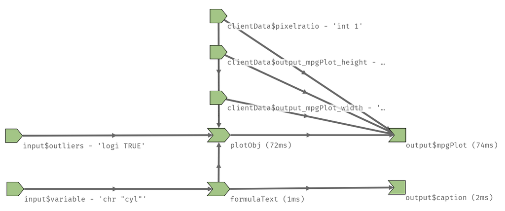

📁 session_01/intro_app

## Concepts

**Reactive source**

A source of data that can tell dependent objects that they need to re-execute. Usually a user input from the browser.

**Reactive endpoint**

An expression performing an action that will re-execute when its dependencies change. Actions include rendering content in the browser.

**Reactive conductor**

An expression inside the reactive graph, that can use and be used by other reactive components. Often used to encapsulate code used in multiple places, like a function.

## Inputs and Outputs

Reactive UI elements

#### UI inputs - `input$*`

- Triggers updates in dependent expressions
- *Reactive source* used to access values from user input

#### UI outputs - `output$* <- render*()`

- `render*()` function re-executed as soon as dependencies change
- *Reactive endpoint* used to render content to the browser

## Expressions and Observers

Expressions that are re-executed when their dependencies change

#### Reactive expressions - `reactive()`

- Evaluated *lazily*, only when they are called by dependent expressions
- *Reactive conductor* used in other reactives - create a calculated value

#### Observers - `observe()`

- Evaluated *eagerly*, as soon as dependencies change
- *Reactive endpoint* used for side effects - perform an action

📁 session_01/reactive_observe.R

## Events

Instead of changing with their input values, reactives can be triggered by an event

- Use `bindEvent()` to create an event reactive
- Often used with buttons

```r
# Update when input$variable changes
formula_text <- reactive(
  paste("mpg ~", input$variable)
)

# Updated when the button
# input$my_button is pressed
formula_text <- reactive(
  paste("mpg ~", input$variable)
) |>
  bindEvent(input$update)
```

Discussed in more detail in session 4!

📁 session_01/event_reactive.R

# Wrapping up

## Homework - Readings

### Mastering Shiny

**[Chapter 2: Basic UI](https://mastering-shiny.org/basic-ui.html)**: Introduction to common input and output elements

**[Chapter 3: Basic Reactivity](https://mastering-shiny.org/basic-reactivity.html)**: Introduction to reactivity and the server function

**[Chapter 4: Case study: ER injuries](https://mastering-shiny.org/basic-case-study.html)**: Detailed example of building a Shiny application from scratch

### Shiny articles

**[Reactivity - An overview](https://shiny.rstudio.com/articles/reactivity-overview.html)**: Shiny introduction to reactivity

## Homework - Exercise

Create a Shiny application!

- Add a few input elements
  - Data filters
  - Output options
- Add dynamic output elements that change based on the input
  - A table of data
  - A simple plot
- Use a `reactive()` expression
  - A common reactive data source for multiple outputs
  - Add a button

We’ll go into layout in detail in session 2…

## Goodbye!

### Next Session

2. *Shiny UI - layout, styling and theming*

**Introduction to Shiny** Session 1: *Introduction to Shiny*